# Lab3A

Anastasia Galperina

9/7/2020

```r
  library(tidyverse)
```

## Download data into data folder

```r
   download.file(url="https://ndownloader.figshare.com/files/2292169",
              destfile = "data/portal_data_joined.csv")
```

```r
  surveys <- read_csv("data/portal_data_joined.csv")
  head(surveys)
```

```
## # A tibble: 6 x 13
##   record_id month   day  year plot_id species_id sex   hindfoot_length
##       <dbl> <dbl> <dbl> <dbl>   <dbl> <chr>      <chr>           <dbl>
## 1         1     7    16  1977       2 NL         M                  32
## 2        72     8    19  1977       2 NL         M                  31
## 3       224     9    13  1977       2 NL         <NA>               NA
## 4       266    10    16  1977       2 NL         <NA>               NA
## 5       349    11    12  1977       2 NL         <NA>               NA
## 6       363    11    12  1977       2 NL         <NA>               NA
## # … with 5 more variables: weight <dbl>, genus <chr>, species <chr>,
## #   taxa <chr>, plot_type <chr>
```

# Challenge 1

```r
  str(surveys)
```

```
## tibble [34,786 × 13] (S3: spec_tbl_df/tbl_df/tbl/data.frame)
##  $ record_id      : num [1:34786] 1 72 224 266 349 363 435 506 588 661 ...
##  $ month          : num [1:34786] 7 8 9 10 11 11 12 1 2 3 ...
##  $ day            : num [1:34786] 16 19 13 16 12 12 10 8 18 11 ...
##  $ year           : num [1:34786] 1977 1977 1977 1977 1977 ...
##  $ plot_id        : num [1:34786] 2 2 2 2 2 2 2 2 2 2 ...
##  $ species_id     : chr [1:34786] "NL" "NL" "NL" "NL" ...
##  $ sex            : chr [1:34786] "M" "M" NA NA ...
##  $ hindfoot_length: num [1:34786] 32 31 NA NA NA NA NA NA NA NA ...
##  $ weight         : num [1:34786] NA NA NA NA NA NA NA NA 218 NA ...
##  $ genus          : chr [1:34786] "Neotoma" "Neotoma" "Neotoma" "Neotoma" ...
##  $ species        : chr [1:34786] "albigula" "albigula" "albigula" "albigula" ...
##  $ taxa           : chr [1:34786] "Rodent" "Rodent" "Rodent" "Rodent" ...
##  $ plot_type      : chr [1:34786] "Control" "Control" "Control" "Control" ...
##  - attr(*, "spec")=
##   .. cols(
##   ..   record_id = col_double(),
##   ..   month = col_double(),
##   ..   day = col_double(),
##   ..   year = col_double(),
##   ..   plot_id = col_double(),
##   ..   species_id = col_character(),
##   ..   sex = col_character(),
##   ..   hindfoot_length = col_double(),
##   ..   weight = col_double(),
##   ..   genus = col_character(),
##   ..   species = col_character(),
##   ..   taxa = col_character(),
##   ..   plot_type = col_character()
##   .. )
```

What is the class of the object surveys?

Class: Data Frame

How many rows and how many columns are in this object?

Rows: 34786 ; Columns: 13

How many species have been recorded during these surveys?

Species: 48

# Indexing and Subsetting

```r
  # first element in the first column of the data frame (as a vector)
  surveys[1, 1]
  # first element in the 6th column (as a vector)
  surveys[1, 6]
  # first column of the data frame (as a vector)
  surveys[, 1]
  # first column of the data frame (as a data.frame)
  surveys[1]
  # first three elements in the 7th column (as a vector)
  surveys[1:3, 7]
  # the 3rd row of the data frame (as a data.frame)
  surveys[3, ]
  # equivalent to head_surveys <- head(surveys)
  head_surveys <- surveys[1:6, ]
  # The whole data frame, except the first column
  surveys[, -1]
  # Equivalent to head(surveys)
  surveys[-(7:34786), ]

  surveys["species_id"]       # Result is a data.frame
  surveys[, "species_id"]     # Result is a vector
  surveys[["species_id"]]     # Result is a vector
  surveys$species_id          # Result is a vector
```

Results above are set to hidden

# Challenge 2

```r
  # Question 1
    surveys_200 <- surveys[200, ]
  # Question 2
    tail(surveys)
```

```
## # A tibble: 6 x 13
##   record_id month   day  year plot_id species_id sex   hindfoot_length
##       <dbl> <dbl> <dbl> <dbl>   <dbl> <chr>      <chr>           <dbl>
## 1     26787     9    27  1997       7 PL         F                  21
## 2     26966    10    25  1997       7 PL         M                  20
## 3     27185    11    22  1997       7 PL         F                  21
## 4     27792     5     2  1998       7 PL         F                  20
## 5     28806    11    21  1998       7 PX         <NA>               NA
## 6     30986     7     1  2000       7 PX         <NA>               NA
## # … with 5 more variables: weight <dbl>, genus <chr>, species <chr>,
## #   taxa <chr>, plot_type <chr>
```

```r
    n_rows <- nrow(surveys)
    surveys_last <- surveys[n_rows, ]
    surveys_last
```

```
## # A tibble: 1 x 13
##   record_id month   day  year plot_id species_id sex   hindfoot_length
##       <dbl> <dbl> <dbl> <dbl>   <dbl> <chr>      <chr>           <dbl>
## 1     30986     7     1  2000       7 PX         <NA>               NA
## # … with 5 more variables: weight <dbl>, genus <chr>, species <chr>,
## #   taxa <chr>, plot_type <chr>
```

```r
  # Question 3
    surveys_middle <- surveys[n_rows / 2, ]
    surveys_middle
```

```
## # A tibble: 1 x 13
##   record_id month   day  year plot_id species_id sex   hindfoot_length
##       <dbl> <dbl> <dbl> <dbl>   <dbl> <chr>      <chr>           <dbl>
## 1      9828     1    19  1985      14 AB         <NA>               NA
## # … with 5 more variables: weight <dbl>, genus <chr>, species <chr>,
## #   taxa <chr>, plot_type <chr>
```

```r
  # Question 4
    surveys_head <- surveys[-(7:n_rows), ]
    surveys_head
```

```
## # A tibble: 6 x 13
##   record_id month   day  year plot_id species_id sex   hindfoot_length
##       <dbl> <dbl> <dbl> <dbl>   <dbl> <chr>      <chr>           <dbl>
## 1         1     7    16  1977       2 NL         M                  32
## 2        72     8    19  1977       2 NL         M                  31
## 3       224     9    13  1977       2 NL         <NA>               NA
## 4       266    10    16  1977       2 NL         <NA>               NA
## 5       349    11    12  1977       2 NL         <NA>               NA
## 6       363    11    12  1977       2 NL         <NA>               NA
## # … with 5 more variables: weight <dbl>, genus <chr>, species <chr>,
## #   taxa <chr>, plot_type <chr>
```

# Factors

```r
  sex <- factor(c("male", "female", "female", "male"))
```

```r
   levels(sex)
```

```
## [1] "female" "male"
```

```r
   nlevels(sex)
```

```
## [1] 2
```

```r
  sex
```

```
## [1] male   female female male
## Levels: female male
```

```r
  sex <- factor(sex, levels = c("male", "female"))
  sex
```

```
## [1] male   female female male
## Levels: male female
```

```r
  as.character(sex)
```

```r
  year_fct <- factor(c(1990, 1983, 1977, 1998, 1990))
  as.numeric(levels(year_fct))[year_fct]    # The recommended way.
```

```
## [1] 1990 1983 1977 1998 1990
```

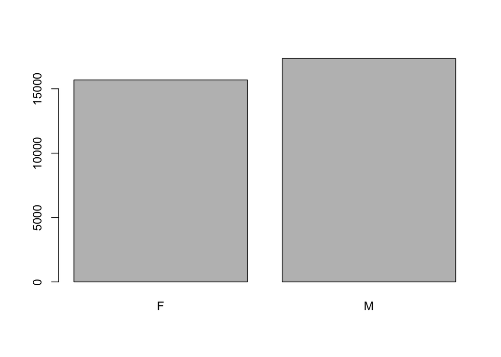

```r
  plot(as.factor(surveys$sex))
```

```r
   sex <- factor(surveys$sex)
   head(sex)
```

```
## [1] M    M    <NA> <NA> <NA> <NA>
## Levels: F M
```

```r
  levels(sex)
```

```
## [1] "F" "M"
```

```r
  levels(sex)[1] <- "undetermined"
  levels(sex)
```

```
## [1] "undetermined" "M"
```

```r
  head(sex)
```

```
## [1] M    M    <NA> <NA> <NA> <NA>
## Levels: undetermined M
```

# Challenge 3

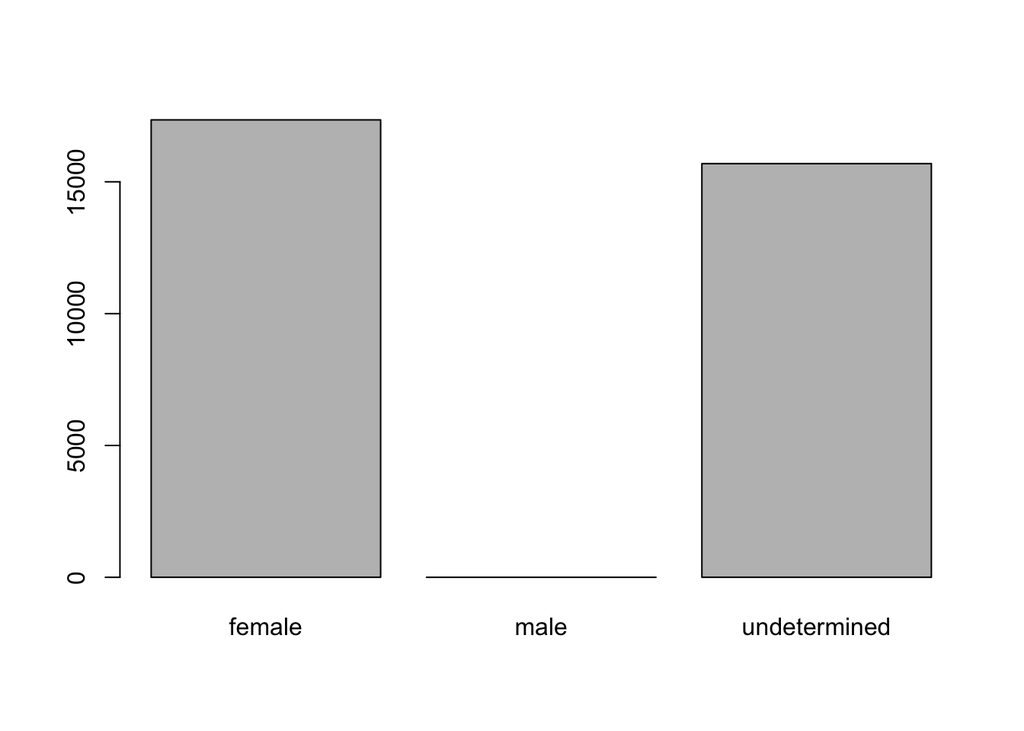

```r
  levels(sex)[2:3] <- c("female", "male")
  sex <- factor(sex, levels = c("female", "male", "undetermined"))
  plot(sex)
```

```r
## Compare the difference between our data read as `factor` vs `character`.
surveys <- read.csv("data/portal_data_joined.csv", stringsAsFactors = TRUE)
str(surveys)
```

```
## 'data.frame':    34786 obs. of  13 variables:
##  $ record_id      : int  1 72 224 266 349 363 435 506 588 661 ...
##  $ month          : int  7 8 9 10 11 11 12 1 2 3 ...
##  $ day            : int  16 19 13 16 12 12 10 8 18 11 ...
##  $ year           : int  1977 1977 1977 1977 1977 1977 1977 1978 1978 1978 ...
##  $ plot_id        : int  2 2 2 2 2 2 2 2 2 2 ...
##  $ species_id     : Factor w/ 48 levels "AB","AH","AS",..: 16 16 16 16 16 16 16 16 16 16 ...
##  $ sex            : Factor w/ 3 levels "","F","M": 3 3 1 1 1 1 1 1 3 1 ...
##  $ hindfoot_length: int  32 31 NA NA NA NA NA NA NA NA ...
##  $ weight         : int  NA NA NA NA NA NA NA NA 218 NA ...
##  $ genus          : Factor w/ 26 levels "Ammodramus","Ammospermophilus",..: 13 13 13 13 13 13 13 13 13 13 ...
##  $ species        : Factor w/ 40 levels "albigula","audubonii",..: 1 1 1 1 1 1 1 1 1 1 ...
##  $ taxa           : Factor w/ 4 levels "Bird","Rabbit",..: 4 4 4 4 4 4 4 4 4 4 ...
##  $ plot_type      : Factor w/ 5 levels "Control","Long-term Krat Exclosure",..: 1 1 1 1 1 1 1 1 1 1 ...
```

```r
surveys <- read.csv("data/portal_data_joined.csv", stringsAsFactors = FALSE)
str(surveys)
```

```
## 'data.frame':    34786 obs. of  13 variables:
##  $ record_id      : int  1 72 224 266 349 363 435 506 588 661 ...
##  $ month          : int  7 8 9 10 11 11 12 1 2 3 ...
##  $ day            : int  16 19 13 16 12 12 10 8 18 11 ...
##  $ year           : int  1977 1977 1977 1977 1977 1977 1977 1978 1978 1978 ...
##  $ plot_id        : int  2 2 2 2 2 2 2 2 2 2 ...
##  $ species_id     : chr  "NL" "NL" "NL" "NL" ...
##  $ sex            : chr  "M" "M" "" "" ...
##  $ hindfoot_length: int  32 31 NA NA NA NA NA NA NA NA ...
##  $ weight         : int  NA NA NA NA NA NA NA NA 218 NA ...
##  $ genus          : chr  "Neotoma" "Neotoma" "Neotoma" "Neotoma" ...
##  $ species        : chr  "albigula" "albigula" "albigula" "albigula" ...
##  $ taxa           : chr  "Rodent" "Rodent" "Rodent" "Rodent" ...
##  $ plot_type      : chr  "Control" "Control" "Control" "Control" ...
```

```r
## Convert the column "plot_type" into a factor
surveys$plot_type <- factor(surveys$plot_type)
```

# Challenge 4

```r
      animal_data <- data.frame(
              animal = c("dog", "cat", "sea cucumber", "sea urchin"),
              feel = c("furry","furry", "squishy", "spiny"),
              weighlabt = c(45, 8, 1.1, 0.8)
              )

      country_climate <- data.frame(
           country = c("Canada", "Panama", "South Africa", "Australia"),
           climate = c("cold", "hot", "temperate", "hot/temperate"),
           temperature = c(10, 30, 18, 15),
           northern_hemisphere = c(TRUE, TRUE, FALSE, FALSE),
           has_kangaroo = c(FALSE, FALSE, FALSE, TRUE)
           )
```

Can you predict the class for each of the columns in the following example? Check your guesses using str(country_climate): Are they what you expected? Why? Why not?

What would have been different if we had added stringsAsFactors = FALSE when creating the data frame?

using stringsAsFactors = FALSE would have made character vectors instead of factors

What would you need to change to ensure that each column had the accurate data type?

```r
  library("lubridate")
```

# Formatting Dates

```r
  my_date <- ymd("2015-01-01")
  str(my_date)
```

```
##  Date[1:1], format: "2015-01-01"
```

```r
  my_date <- ymd(paste("2015", "1", "1", sep = "-"))
  str(my_date)
```

```
##  Date[1:1], format: "2015-01-01"
```

```r
  head(paste(surveys$year, surveys$month, surveys$day, sep = "-"))
```

```
## [1] "1977-7-16"  "1977-8-19"  "1977-9-13"  "1977-10-16" "1977-11-12"
## [6] "1977-11-12"
```

```r
  head(ymd(paste(surveys$year, surveys$month, surveys$day, sep = "-")))
```

```
## [1] "1977-07-16" "1977-08-19" "1977-09-13" "1977-10-16" "1977-11-12"
## [6] "1977-11-12"
```

```r
  head(surveys$date <- ymd(paste(surveys$year, surveys$month, surveys$day, sep = "-")))
```

```
## [1] "1977-07-16" "1977-08-19" "1977-09-13" "1977-10-16" "1977-11-12"
## [6] "1977-11-12"
```

```r
  str(surveys)
```

```
## 'data.frame':    34786 obs. of  14 variables:
##  $ record_id      : int  1 72 224 266 349 363 435 506 588 661 ...
##  $ month          : int  7 8 9 10 11 11 12 1 2 3 ...
##  $ day            : int  16 19 13 16 12 12 10 8 18 11 ...
##  $ year           : int  1977 1977 1977 1977 1977 1977 1977 1978 1978 1978 ...
##  $ plot_id        : int  2 2 2 2 2 2 2 2 2 2 ...
##  $ species_id     : chr  "NL" "NL" "NL" "NL" ...
##  $ sex            : chr  "M" "M" "" "" ...
##  $ hindfoot_length: int  32 31 NA NA NA NA NA NA NA NA ...
##  $ weight         : int  NA NA NA NA NA NA NA NA 218 NA ...
##  $ genus          : chr  "Neotoma" "Neotoma" "Neotoma" "Neotoma" ...
##  $ species        : chr  "albigula" "albigula" "albigula" "albigula" ...
##  $ taxa           : chr  "Rodent" "Rodent" "Rodent" "Rodent" ...
##  $ plot_type      : Factor w/ 5 levels "Control","Long-term Krat Exclosure",..: 1 1 1 1 1 1 1 1 1 1 ...
##  $ date           : Date, format: "1977-07-16" "1977-08-19" ...
```

```r
  summary(surveys$date)
```

```
##         Min.      1st Qu.       Median         Mean      3rd Qu.
## "1977-07-16" "1984-03-12" "1990-07-22" "1990-12-15" "1997-07-29"
##         Max.         NA's
## "2002-12-31"        "129"
```

```r
  missing_dates <- surveys[is.na(surveys$date), c("year", "month", "day")]
  head(missing_dates)
```

```
##      year month day
## 3144 2000     9  31
## 3817 2000     4  31
## 3818 2000     4  31
## 3819 2000     4  31
## 3820 2000     4  31
## 3856 2000     9  31
```